# Location-intelligentieanalyse — Gents winkelnetwerk

Ruimtelijke demonstratie met officiële Gentse wijkgrenzen

Dr. Kuralarasan Kumar

kuralarasan.kumar@ugent.be · +32 467 66 70 48

## Overzicht

Deze analyse plaatst een **realistisch synthetisch netwerk van 65 Delhaize-winkels binnen de echte grenzen van Gent**, op basis van de officiële polygonen van de Gentse *stadswijken*. De winkellocaties, winkelformaten en variabelen voor het verzorgingsgebied zijn gesimuleerd zodat ze aansluiten bij de echte stedelijke geografie van Gent: dichtbevolkte buurten rond het historisch centrum, residentiële zones in het zuiden en westen, studentenbuurten rond UGent-campussen en meer perifere wijken.

De demonstratie toont drie analytische onderdelen:

1. **Modellering van winkelprestaties** — OLS-regressie van wekelijkse omzet op socio-economische, structurele en bereikbaarheidsvariabelen
2. **MAUP (Modifiable Areal Unit Problem; aanpasbaar ruimtelijk eenheidsprobleem)** — hoe regressiecoëfficiënten veranderen wanneer het verzorgingsgebied anders wordt afgebakend
3. **Vergelijking van ruimtelijke eenheden** — puntniveau (winkel), buffer/verzorgingsgebied en wijkpolygonen, weergegeven op echte kaarten

De opbouw sluit aan bij de functievereisten van de **Location Intelligence Analyst**: geografische inplanting koppelen aan **rentabiliteit en omzetverwachting**, geografische parameters samenbrengen met **business performance** en **concurrentiedata**, socio-economische indicatoren opvolgen en de resultaten vertalen naar managementadvies over **opening, uitbreiding, optimalisatie of sluiting** van winkels.

## 1. Gentse wijkgrenzen laden

## 2. Synthetische winkels in Gent plaatsen

Voor de demonstratie simuleren we **65 winkels** met een plausibele mix van formaten en een ruimtelijke spreiding die past bij Gent: Shop&Go meer rond centrum en stations, Proxy Delhaize in binnenstedelijke woonbuurten en AD Delhaize vaker aan de stedelijke rand.

Samenvatting van het winkelnetwerk per formaat (Gent, n=65)

| Formaat | n | Gem. omzet (k€/week) | Gem. oppervlakte (m2) | Gem. concurrenten | % nabij transport |
| --- | --- | --- | --- | --- | --- |
| AD Delhaize | 26 | 468.2 | 2088 | 5.7 | 4 |
| Proxy Delhaize | 22 | 193.5 | 550 | 8.0 | 23 |
| Shop&Go | 17 | 148.0 | 119 | 8.8 | 59 |

## 3. Ruimtelijke spreiding van het winkelnetwerk

### 3.1 Winkellocaties per formaat

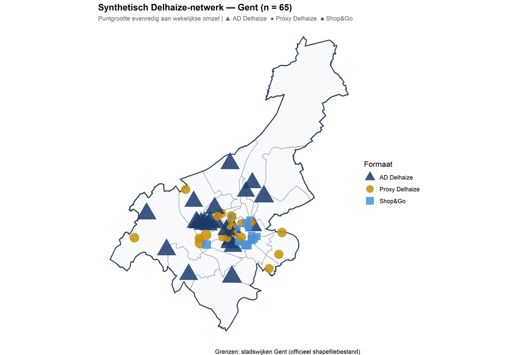

De kaart toont de ruimtelijke spreiding van winkellocaties, winkelformaten en relatieve weekomzet. De puntgrootte geeft aan welke winkels commercieel zwaarder wegen; zo is in één oogopslag zichtbaar waar het netwerk geconcentreerd is, waar de dekking dunner is en waar opening, uitbreiding of optimalisatie het meest voor de hand ligt.

### 3.2 Bevolkingsdichtheid per wijk

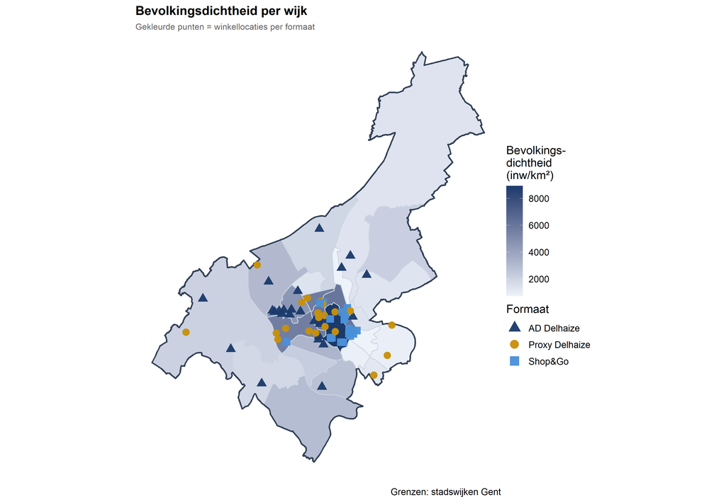

De kaart combineert bevolkingsdichtheid met de gesimuleerde winkellocaties om te tonen of winkels in zones met voldoende klantenpotentieel liggen. Dichte buurten creëren meer vraag, maar brengen ook meer concurrentie en complexere bereikbaarheid mee. In een productieomgeving wordt deze laag aangevuld met Statbel-data, klantenstromen en interne Delhaize-gegevens.

### 3.3 Verzorgingsgebiedbuffers — MAUP visueel gemaakt

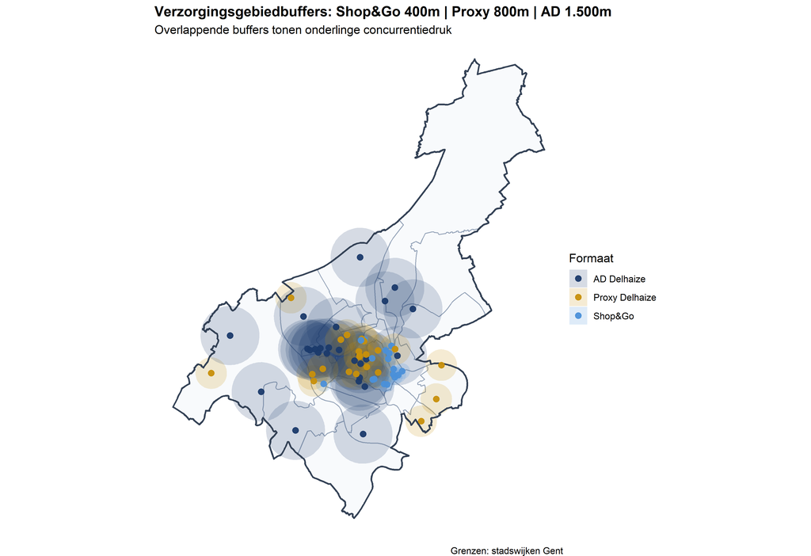

De figuur visualiseert het verzorgingsgebied per winkelformaat met formaatspecifieke bufferafstanden. Overlappende zones wijzen op mogelijke kannibalisatie binnen het eigen netwerk. Omdat een Shop&Go, Proxy en AD Delhaize niet dezelfde ruimtelijke reikwijdte hebben, is de keuze van de trade-area-definitie bepalend voor de betrouwbaarheid van omzetmodellen en locatieadviezen.

### 3.4 Gemiddelde omzet per wijk

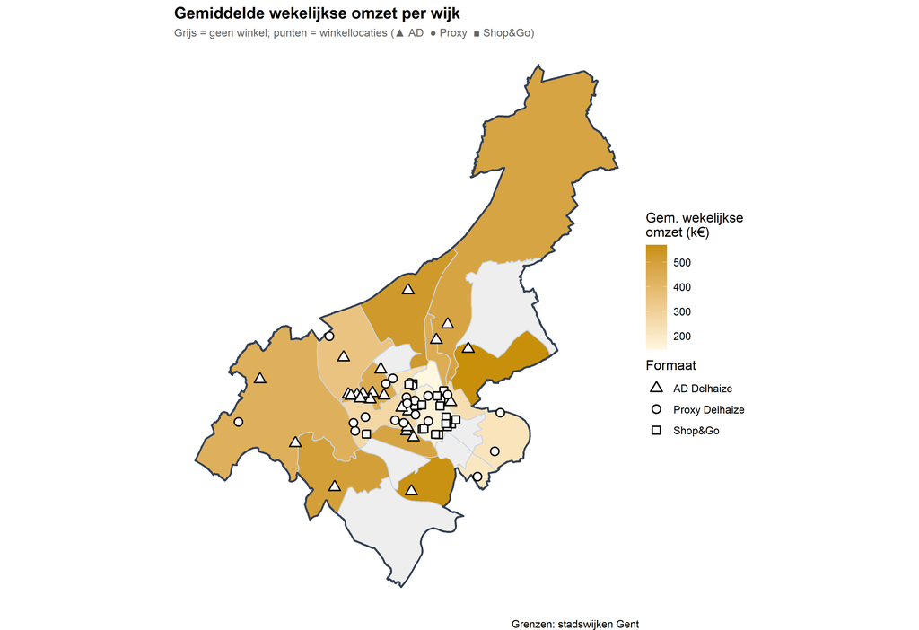

De kaart vat de gesimuleerde omzetprestatie samen op wijkniveau. Donkere zones hebben een hogere gemiddelde weekomzet en komen daardoor in aanmerking voor verdere analyse, uitbreiding of herpositionering. In een echte Delhaize-analyse wordt de synthetische omzet rechtstreeks vervangen door POS- of ERP-data.

## 4. Beschrijvende statistiek

Beschrijvende statistiek per formaat (Gent, n=65)

| Formaat | n | Gem. omzet (k€) | SD omzet | Gem. oppervlakte (m2) | Gem. bevolkingsdichtheid | Gem. inkomensindex | Gem. concurrenten | % knooppunt | % transport | Gem. parking |
| --- | --- | --- | --- | --- | --- | --- | --- | --- | --- | --- |
| AD Delhaize | 26 | 468.2 | 67.0 | 2088 | 3775 | 92.8 | 5.7 | 54 | 4 | 223 |
| Proxy Delhaize | 22 | 193.5 | 53.5 | 550 | 5041 | 91.4 | 8.0 | 36 | 23 | 27 |
| Shop&Go | 17 | 148.0 | 32.8 | 119 | 6877 | 94.4 | 8.8 | 18 | 59 | 3 |

## 5. MAUP: effect van ruimtelijke eenheid op coëfficiënten

Het **Modifiable Areal Unit Problem (MAUP; aanpasbaar ruimtelijk eenheidsprobleem)** is belangrijk in ruimtelijke analyse van retaillocaties. Wanneer we bevolkingsdichtheid of het aantal concurrenten per winkel meten, hangt de uitkomst sterk af van de grootte van het verzorgingsgebied. Een nauwe buffer van 400 meter in een dichte centrumwijk geeft een ander beeld dan een buffer van 1.500 meter of het volledige administratieve wijkpolygoon.

Mijn werkpaper over ruimtelijke analyse-eenheden in locatiekeuzestudies documenteert dit effect systematisch. Dezelfde methodologische waarschuwing geldt ook voor modellen van retaillocaties.

MAUP: coëfficiënten onder drie definities van ruimtelijke eenheid (Gent)

| spatial_unit | term | estimate | conf.low | conf.high | p.value |
| --- | --- | --- | --- | --- | --- |
| Nauw (400 m, alle winkels) | Oppervlakte (m2) | 0.049 | 0.035 | 0.063 | <0.001 |
| Nauw (400 m, alle winkels) | Bevolkingsdichtheid | 0.009 | 0.002 | 0.016 | 0.01 |
| Nauw (400 m, alle winkels) | Inkomensindex | 1.064 | 0.244 | 1.884 | 0.012 |
| Nauw (400 m, alle winkels) | Aantal concurrenten | -23.255 | -26.133 | -20.376 | <0.001 |
| Formaatspecifieke buffer | Oppervlakte (m2) | 0.049 | 0.035 | 0.063 | <0.001 |
| Formaatspecifieke buffer | Bevolkingsdichtheid | 0.012 | 0.003 | 0.022 | 0.01 |
| Formaatspecifieke buffer | Inkomensindex | 1.064 | 0.244 | 1.884 | 0.012 |
| Formaatspecifieke buffer | Aantal concurrenten | -12.790 | -14.373 | -11.207 | <0.001 |
| Wijkpolygoon | Oppervlakte (m2) | 0.049 | 0.035 | 0.063 | <0.001 |
| Wijkpolygoon | Bevolkingsdichtheid | 0.018 | 0.004 | 0.031 | 0.01 |
| Wijkpolygoon | Inkomensindex | 1.064 | 0.244 | 1.884 | 0.012 |
| Wijkpolygoon | Aantal concurrenten | -7.994 | -8.983 | -7.004 | <0.001 |

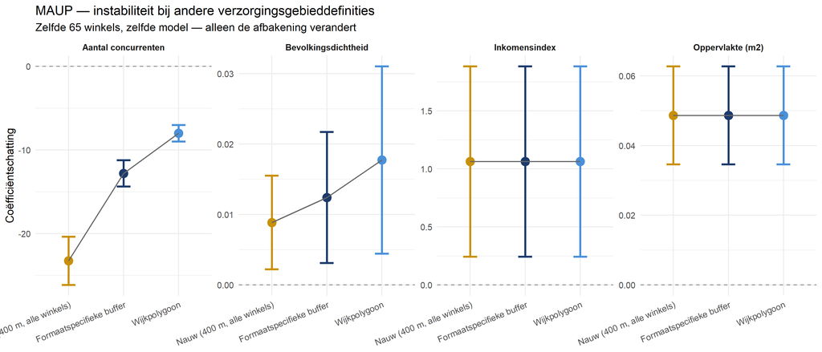

De figuur dient als kwaliteitscontrole voor ruimtelijk locatieadvies. Ze toont hoe modeluitkomsten veranderen wanneer dezelfde winkels op een andere ruimtelijke eenheid worden geanalyseerd. Stabiele factoren zijn robuuster voor managementbeslissingen dan factoren die sterk afhangen van de gekozen gebiedsafbakening.

## 6. Meervoudig regressiemodel

OLS-regressie: wekelijkse omzet ~ alle voorspellers (Gent, n=65)

| term | estimate | std.error | statistic | p.value | conf.low | conf.high | sig |
| --- | --- | --- | --- | --- | --- | --- | --- |
| Intercept | 255.845 | 55.119 | 4.6416713 | <0.001 | 145.189 | 366.501 | *** |
| Formaat: Proxy (ref=AD) | -154.674 | 15.304 | -10.1068775 | <0.001 | -185.398 | -123.950 | *** |
| Formaat: Shop&Go (ref=AD) | -210.690 | 19.390 | -10.8661742 | <0.001 | -249.616 | -171.764 | *** |
| Oppervlakte (m2) | 0.049 | 0.007 | 6.9556363 | <0.001 | 0.035 | 0.063 | *** |
| Bevolkingsdichtheid | 0.012 | 0.005 | 2.6791708 | 0.01 | 0.003 | 0.022 | ** |
| Inkomensindex | 1.064 | 0.409 | 2.6043154 | 0.012 | 0.244 | 1.884 | * |
| Studenten (%) | 0.141 | 0.751 | 0.1872814 | 0.852 | -1.368 | 1.649 |  |
| 65+ (%) | 0.464 | 0.723 | 0.6413587 | 0.524 | -0.988 | 1.916 |  |
| Autobezit (%) | -0.766 | 0.396 | -1.9336947 | 0.059 | -1.562 | 0.029 | . |
| Concurrenten (1 km) | -12.790 | 0.788 | -16.2208445 | <0.001 | -14.373 | -11.207 | *** |
| Retaildichtheid | 0.410 | 0.262 | 1.5659963 | 0.124 | -0.116 | 0.936 |  |
| Nabij knooppunt | 13.164 | 4.903 | 2.6851313 | 0.01 | 3.322 | 23.007 | ** |
| Nabij vervoersknooppunt | 26.082 | 6.486 | 4.0216129 | <0.001 | 13.062 | 39.102 | *** |
| Parkeerplaatsen | 0.216 | 0.054 | 4.0184896 | <0.001 | 0.108 | 0.324 | *** |

Statistieken voor modelkwaliteit

| r.squared | adj.r.squared | sigma | statistic | p.value | AIC | nobs |
| --- | --- | --- | --- | --- | --- | --- |
| 0.99 | 0.988 | 17.088 | 407.857 | 0 | 567.681 | 65 |

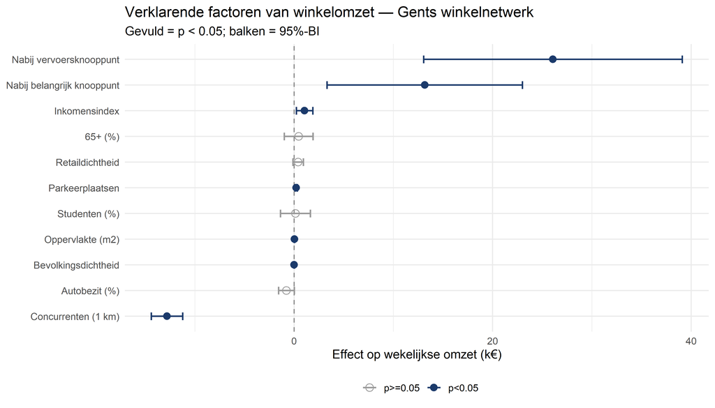

Het diagram vertaalt het regressiemodel naar concrete beslissingsfactoren. Factoren rechts van nul verhogen de verwachte omzet; factoren links van nul verlagen ze. De betrouwbaarheidsintervallen tonen welke effecten robuust zijn en waar extra businessdata de precisie van locatiebeoordelingen kan verbeteren.

## 7. Impact van concurrentie en bereikbaarheid

Omzetimpact: concurrentie en bereikbaarheid (Gents model)

| Scenario | Wekelijks (k€) | Jaarlijks (k€) |
| --- | --- | --- |
| 1 extra concurrent (1 km) | -12.8 | -665 |
| 2 extra concurrenten | -25.6 | -1330 |
| 3 extra concurrenten | -38.4 | -1995 |
| Nabij belangrijk verkeersknooppunt | 13.2 | 685 |
| Nabij vervoersknooppunt | 26.1 | 1356 |
| Verkeersknooppunt + vervoersknooppunt | 39.2 | 2041 |

## 8. Visuele gevoeligheidsanalyses

De onderstaande figuren tonen hoe de verwachte omzet verandert wanneer één belangrijke verklarende variabele wijzigt. Dit geeft een helder beeld van de gevoeligheid van locatiebeslissingen voor concurrentie, bevolkingsdichtheid, inkomen en bereikbaarheid.

### 8.1 Concurrentiedruk en verwachte omzet

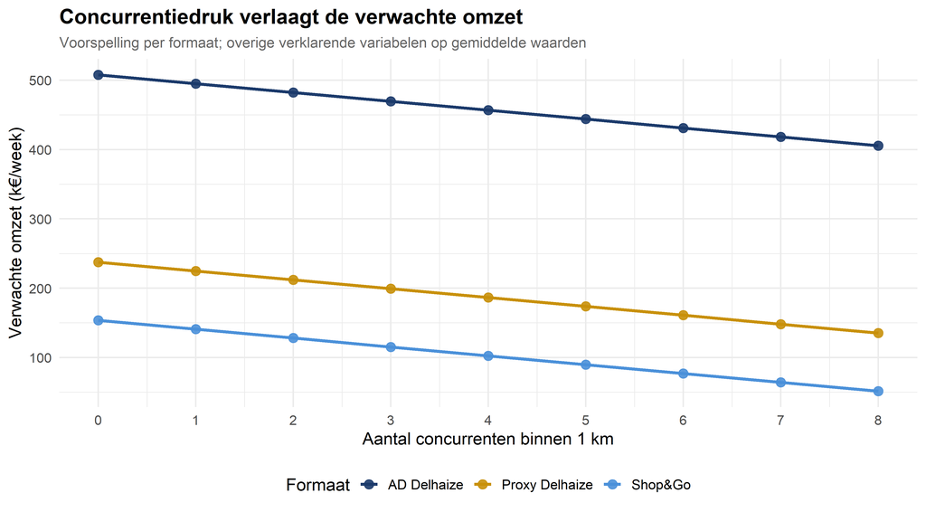

### 8.2 Bevolkingsdichtheid en omzetpotentieel

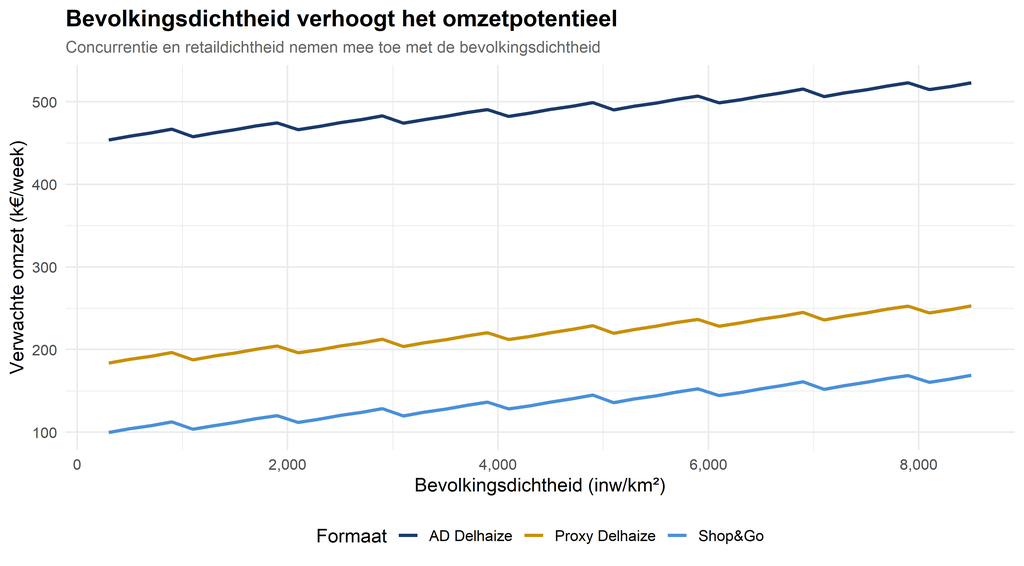

De figuur koppelt bevolkingsdichtheid aan het verwachte omzetpotentieel. Een hogere dichtheid betekent meer potentiële klanten, maar in stedelijke zones nemen ook concurrentie en retaildichtheid toe. Bevolkingsdichtheid wordt daarom niet geïsoleerd geïnterpreteerd, maar samen met winkelformaat, concurrentiedruk en lokale marktinformatie zoals Statbel-data en interne omzetregistraties.

### 8.3 Inkomensindex en verwachte omzet

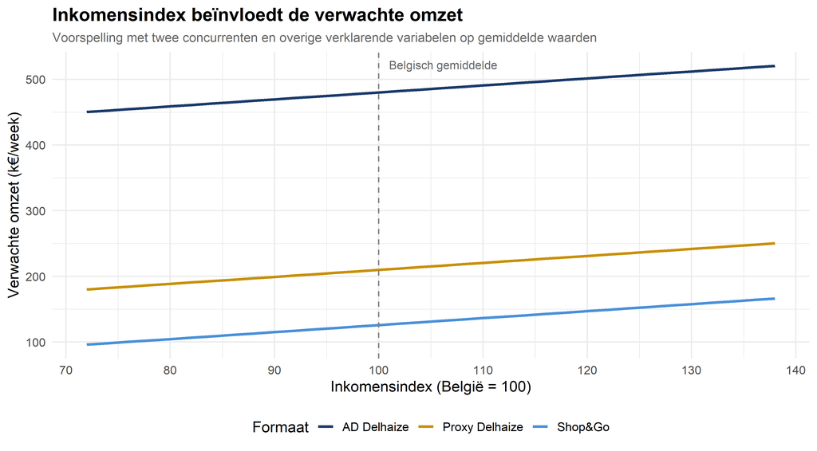

De inkomensindex benadert de lokale koopkracht en socio-economische context van een buurt. In het model stijgt de verwachte omzet met hogere inkomens, wat voor Delhaize relevant is bij formatkeuze, assortimentsstrategie en de interpretatie van gemiddelde mandwaarden. In een productieomgeving wordt deze variabele gekoppeld aan actuele fiscale statistieken van Statbel of andere socio-economische bronnen.

### 8.4 Bereikbaarheid en verwachte omzet

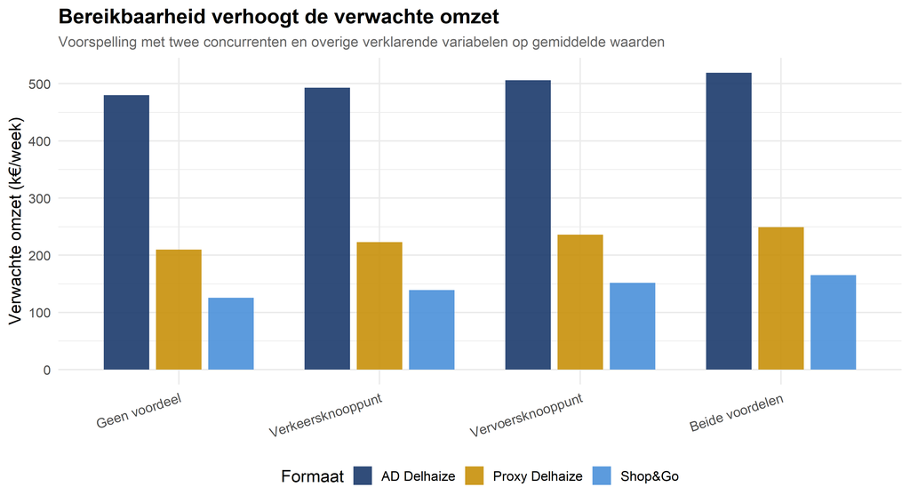

De grafiek vergelijkt vier bereikbaarheidsscenario’s per formaat: geen voordeel, nabijheid van een verkeersknooppunt, nabijheid van een vervoersknooppunt en beide voordelen samen. Zo wordt een geografisch kenmerk direct bruikbaar voor omzetinschatting en managementrapportering. Voor Delhaize sluit dit aan bij de beoordeling van parking, autotoegang, pendelstromen en lokale bereikbaarheid bij nieuwe locaties.

### 8.5 GIF-modelbeeld: concurrentie-effect stap voor stap

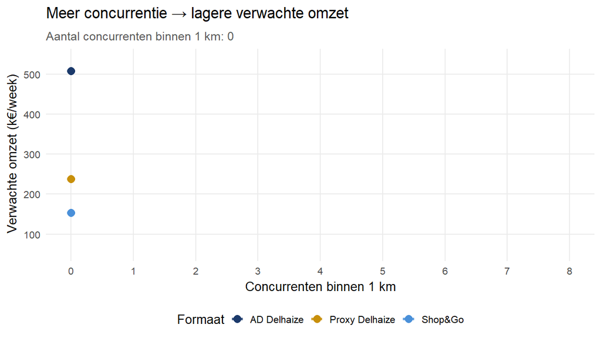

De animatie toont stap voor stap hoe de verwachte omzet daalt naarmate het aantal concurrenten toeneemt. De lezer hoeft geen regressiecoëfficiënten te interpreteren om de commerciële impact te begrijpen, wat de analyse bruikbaar maakt voor presentaties over nieuwe locaties, kannibalisatierisico en de prioritering van vervolgonderzoek.

### 8.6 GIF-modelbeeld: bereikbaarheidsscenario’s

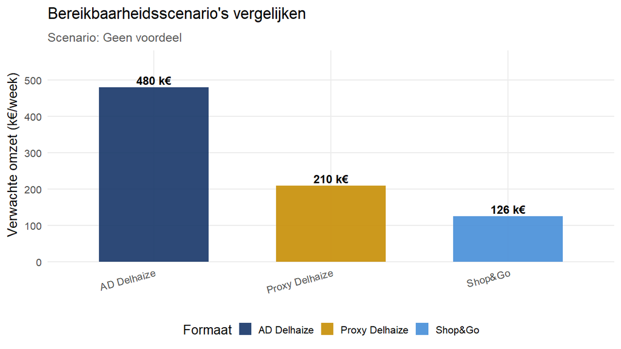

De animatie toont de vier bereikbaarheidsscenario’s één voor één, zodat het commerciële verschil tussen geen voordeel, één voordeel en beide voordelen direct zichtbaar wordt. De visualisatie is bedoeld voor niet-technische stakeholders en ondersteunt gesprekken over locatieopties, bereikbaarheid en verwachte omzet.

## 9. Scenario: drie hypothetische nieuwe Gentse locaties

Voorspelde wekelijkse omzet — drie hypothetische Gentse locaties (90% PI)

| Locatie | Formaat | Voorspeld (k€/week) | 90% PI laag | 90% PI hoog |
| --- | --- | --- | --- | --- |
| A: Dampoort (binnenstedelijk oost) | Proxy Delhaize | 275.7 | 243.7 | 307.6 |
| B: Mariakerke (suburbaan noordwest) | AD Delhaize | 528.4 | 496.4 | 560.5 |
| C: Sint-Amandsberg (residentieel oost) | Proxy Delhaize | 223.6 | 193.1 | 254.0 |

## 10. Belangrijkste bevindingen

Samenvatting: richting, MAUP-gevoeligheid en interpretatie per factor

[output not shown]

## 11. Methodologische nota

Deze demonstratie gebruikt **echte Gentse wijkgrenzen** (officieel shapefilebestand met stadswijken, 25 polygonen). Winkels worden gesimuleerd via willekeurige punten, gewogen naar bevolkingsdichtheid. De analyseworkflow omvat:

- CRS-transformatie naar Belgische Lambert 72 voor afstandsberekeningen
- Concurrentiemeting op basis van de feitelijke afstandsmatrix tussen winkels
- Drie ruimtelijke niveaus voor de MAUP-demonstratie

In productie kan dezelfde analyseworkflow synthetische omzet vervangen door POS-gegevens en synthetische winkellocaties door echte coördinaten.

| Aanpassing | Bron |
| --- | --- |
| Winkelcoördinaten | Delhaize intern |
| Werkelijke omzet | POS- / ERP-systemen |
| Bevolking per verzorgingsgebied | Statbel-statistieken per statistische sector |
| Concurrentielocaties | OSM / Nielsen / interne audit |
| Werkelijk inkomen per zone | Statbel fiscale statistieken |

**Copyright.** Winkellocaties, omzetcijfers en socio-economische parameters zijn synthetisch. Wijkgrenzen: stadswijken Gent (officiële shapefile). Analyse geproduceerd in R (sf, ggplot2, rmarkdown). Deze demonstratie is opgesteld door Dr. Kuralarasan Kumar; gebruik of verspreiding kan met correcte verwijzing naar de auteur. kuralarasan.kumar@ugent.be · +32 467 66 70 48.